# Uncovering the Hidden Drivers of Student Depression: A Data Science Approach Using Lifestyle and Behavioral Patterns

## Section: H, Finalterm Project, Group 8

## Dataset: https://www.kaggle.com/datasets/hopesb/student-depression-dataset

### Packages

```r
packages <- c("ggplot2", "dplyr", "readr", "corrplot", "moments")

installed_packages <- rownames(installed.packages())
for (pkg in packages) {
  if (!(pkg %in% installed_packages)) {
    install.packages(pkg)
  }
}

library(readr)
library(dplyr)
library(ggplot2)
library(corrplot)
library(moments)
```

### A. Data Collection

#### 1. Load the dataset

```r
options(timeout = 300)
url <- "https://raw.githubusercontent.com/salman-sayeed/introduction-to-datascience-finalterm-project/refs/heads/main/Student%20Depression%20Dataset.csv"
data <- read_csv(url)
```

#### 2. Display the first few rows

First 6 rows of Dataset

```r
head(data)
```

```
## # A tibble: 6 × 18
##      id Gender   Age City   Profession `Academic Pressure` `Work Pressure`  CGPA
##   <dbl> <chr>  <dbl> <chr>  <chr>                    <dbl>           <dbl> <dbl>
## 1     2 Male      33 Visak… Student                      5               0  8.97
## 2     8 Female    24 Banga… Student                      2               0  5.9
## 3    26 Male      31 Srina… Student                      3               0  7.03
## 4    30 Female    28 Varan… Student                      3               0  5.59
## 5    32 Female    25 Jaipur Student                      4               0  8.13
## 6    33 Male      29 Pune   Student                      2               0  5.7
## # ℹ 10 more variables: `Study Satisfaction` <dbl>, `Job Satisfaction` <dbl>,
## #   `Sleep Duration` <chr>, `Dietary Habits` <chr>, Degree <chr>,
## #   `Have you ever had suicidal thoughts ?` <chr>, `Work/Study Hours` <dbl>,
## #   `Financial Stress` <dbl>, `Family History of Mental Illness` <chr>,
## #   Depression <dbl>
```

### B. Data Exploration (EDA)

#### 1. Dataset Overview

##### 1.1 Show shape

```r
cat("Dataset Shape: ", nrow(data), "rows x ", ncol(data), "\n")
```

```
## Dataset Shape:  27901 rows x  18
```

##### 1.2. Display data types

Data Types of each column:

```r
glimpse(data)
```

```
## Rows: 27,901
## Columns: 18
## $ id                                      <dbl> 2, 8, 26, 30, 32, 33, 52, 56, …
## $ Gender                                  <chr> "Male", "Female", "Male", "Fem…
## $ Age                                     <dbl> 33, 24, 31, 28, 25, 29, 30, 30…
## $ City                                    <chr> "Visakhapatnam", "Bangalore", …
## $ Profession                              <chr> "Student", "Student", "Student…
## $ `Academic Pressure`                     <dbl> 5, 2, 3, 3, 4, 2, 3, 2, 3, 2, …
## $ `Work Pressure`                         <dbl> 0, 0, 0, 0, 0, 0, 0, 0, 0, 0, …
## $ CGPA                                    <dbl> 8.97, 5.90, 7.03, 5.59, 8.13, …
## $ `Study Satisfaction`                    <dbl> 2, 5, 5, 2, 3, 3, 4, 4, 1, 3, …
## $ `Job Satisfaction`                      <dbl> 0, 0, 0, 0, 0, 0, 0, 0, 0, 0, …
## $ `Sleep Duration`                        <chr> "5-6 hours", "5-6 hours", "Les…
## $ `Dietary Habits`                        <chr> "Healthy", "Moderate", "Health…
## $ Degree                                  <chr> "B.Pharm", "BSc", "BA", "BCA",…
## $ `Have you ever had suicidal thoughts ?` <chr> "Yes", "No", "No", "Yes", "Yes…
## $ `Work/Study Hours`                      <dbl> 3, 3, 9, 4, 1, 4, 1, 0, 12, 2,…
## $ `Financial Stress`                      <dbl> 1, 2, 1, 5, 1, 1, 2, 1, 3, 5, …
## $ `Family History of Mental Illness`      <chr> "No", "Yes", "Yes", "Yes", "No…
## $ Depression                              <dbl> 1, 0, 0, 1, 0, 0, 0, 0, 1, 1, …
```

##### 1.3. Missing values

Missing values per column:

```r
missing_summary <- colSums(is.na(data))
print(missing_summary[missing_summary > 0])
```

```
## Financial Stress
##                3
```

```r
data_clean <- data %>% filter(complete.cases(.))
sum(is.na(data_clean))
```

```
## [1] 0
```

##### 1.4. Type Classification

```r
num_vars_auto <- names(data_clean)[sapply(data_clean, is.numeric)]
cat_vars_auto <- names(data_clean)[sapply(data_clean, is.character)]

cat("\nNumerical Variables:\n", paste(num_vars_auto, collapse = ", "), "\n")
```

```
##
## Numerical Variables:
##  id, Age, Academic Pressure, Work Pressure, CGPA, Study Satisfaction, Job Satisfaction, Work/Study Hours, Financial Stress, Depression
```

```r
cat("\nCategorical Variables:\n", paste(cat_vars_auto, collapse = ", "), "\n")
```

```
##
## Categorical Variables:
##  Gender, City, Profession, Sleep Duration, Dietary Habits, Degree, Have you ever had suicidal thoughts ?, Family History of Mental Illness
```

##### 1.5. Feature Grouping

```r
names(data_clean)
```

```
##  [1] "id"
##  [2] "Gender"
##  [3] "Age"
##  [4] "City"
##  [5] "Profession"
##  [6] "Academic Pressure"
##  [7] "Work Pressure"
##  [8] "CGPA"
##  [9] "Study Satisfaction"
## [10] "Job Satisfaction"
## [11] "Sleep Duration"
## [12] "Dietary Habits"
## [13] "Degree"
## [14] "Have you ever had suicidal thoughts ?"
## [15] "Work/Study Hours"
## [16] "Financial Stress"
## [17] "Family History of Mental Illness"
## [18] "Depression"
```

- Numerical variables

```r
num_vars_manual <- c(
  "Age",
  "CGPA",
  "Academic.Pressure",
  "Financial.Stress",
  "Work.Study.Hours",
  "Study.Satisfaction",
  "Job.Satisfaction"
)
```

- Categorical variables

```r
cat_vars_manual <- c(
  "Gender",
  "City",
  "Degree",
  "Sleep.Duration",
  "Dietary.Habits"
)
```

- Binary variables

```r
binary_vars <- c(
  "Have.you.ever.had.suicidal.thoughts..",
  "Family.History.of.Mental.Illness"
)
```

- Target variable

```r
target_var <- "Depression"
```

-Removing spaces

```r
names(data_clean) <- make.names(names(data_clean))
```

#### 2. Target Variable Analysis

Class balance check

```r
table(data_clean$Depression)
```

```
##
##     0     1
## 11563 16335
```

```r
data_clean$Depression <- as.factor(data_clean$Depression)
```

Class balance in percentage

```r
prop.table(table(data_clean$Depression)) * 100
```

```
##
##        0        1
## 41.44742 58.55258
```

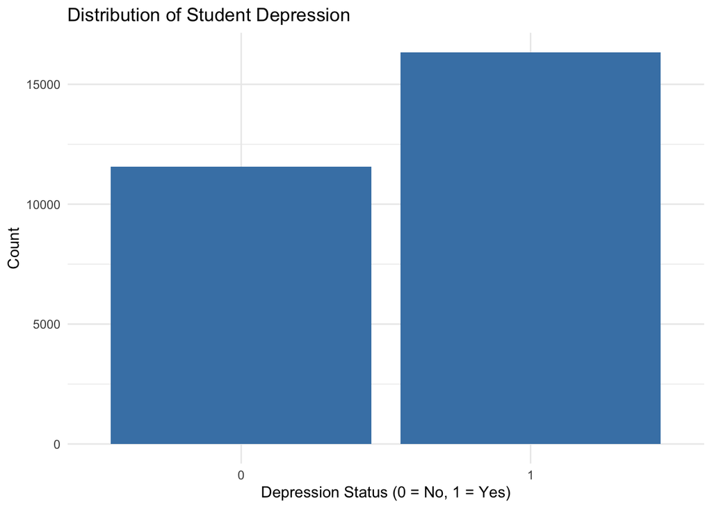

```r
ggplot(data_clean, aes(x = Depression)) +
  geom_bar(fill = "steelblue") +
  labs(
    title = "Distribution of Student Depression",
    x = "Depression Status (0 = No, 1 = Yes)",
    y = "Count"
  ) +
  theme_minimal()
```

#### 3. Univariate Analysis

##### 3.1. Age Distribution

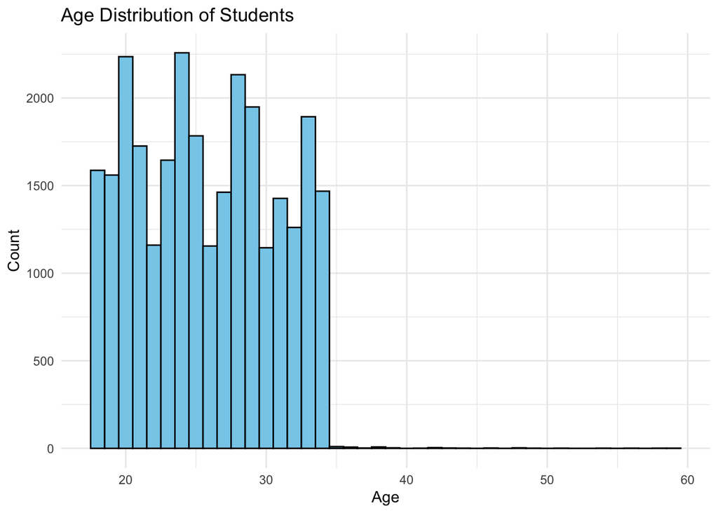

```r
ggplot(data_clean, aes(x = Age)) +
  geom_histogram(binwidth = 1, fill = "skyblue", color = "black") +
  labs(
    title = "Age Distribution of Students",
    x = "Age",
    y = "Count"
  ) +
  theme_minimal()
```

The age distribution shows that most students fall within the young adult range, primarily between late teens and mid 30s. This is expected in an academic dataset and indicates that the analysis focuses on a population that is highly relevant for studying student mental health patterns.

##### 3.2. CGPA Distribution

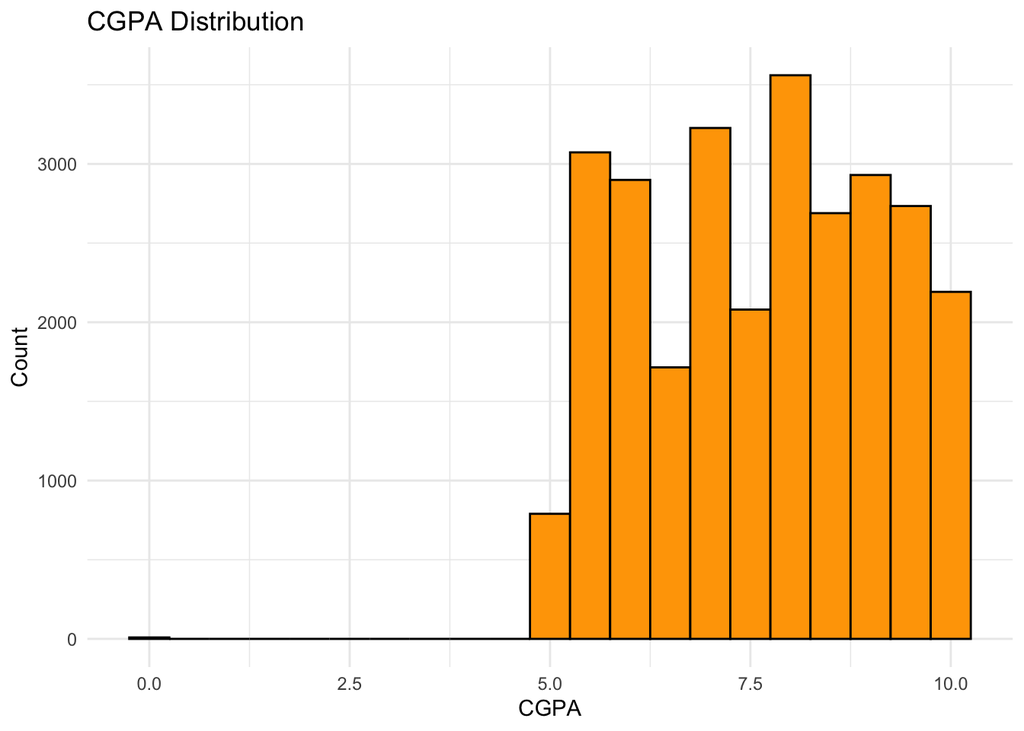

```r
ggplot(data_clean, aes(x = CGPA)) +
  geom_histogram(binwidth = 0.5, fill = "orange", color = "black") +
  labs(
    title = "CGPA Distribution",
    x = "CGPA",
    y = "Count"
  ) +
  theme_minimal()
```

The CGPA (on scale of 10) distribution shows variation in academic performance among students. Most students are concentrated in mid to high CGPA ranges, indicating moderate to good academic performance across the dataset.

##### 3.3. Academic Pressure Distribution

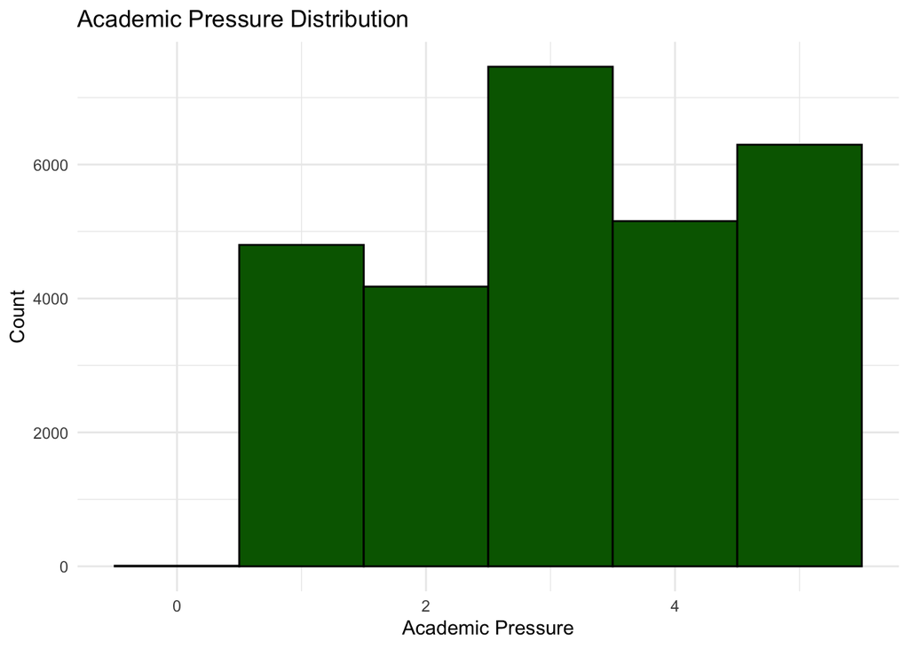

```r
ggplot(data_clean, aes(x = Academic.Pressure)) +
  geom_histogram(binwidth = 1, fill = "darkgreen", color = "black") +
  labs(
    title = "Academic Pressure Distribution",
    x = "Academic Pressure",
    y = "Count"
  ) +
  theme_minimal()
```

Academic pressure is distributed across different levels, with a noticeable concentration in moderate to high pressure ranges. This suggests that academic stress is a common factor among students and may play a significant role in mental health outcomes.

##### 3.4. Financial Stress Distribution

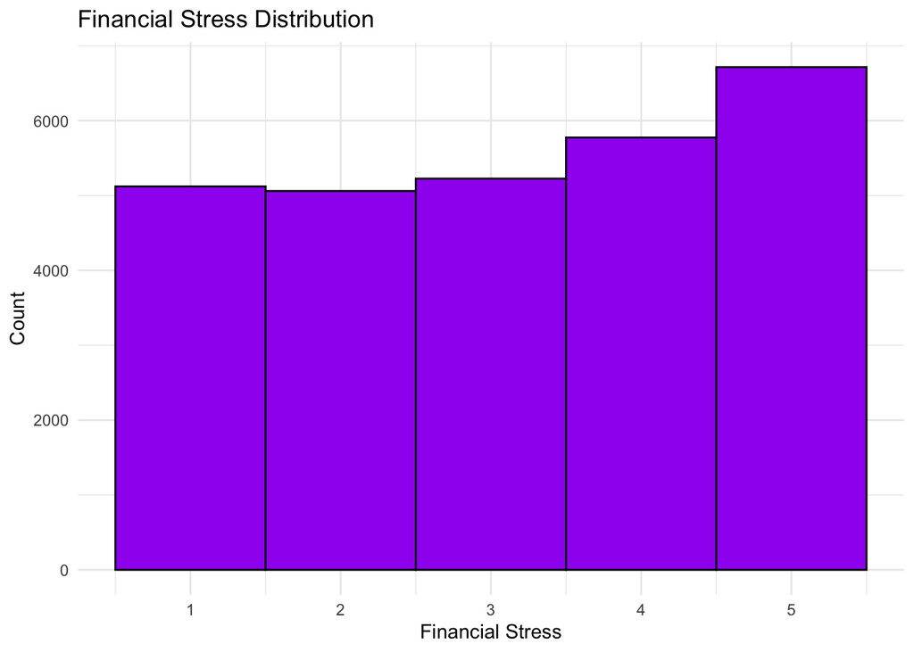

```r
ggplot(data_clean, aes(x = Financial.Stress)) +
  geom_histogram(binwidth = 1, fill = "purple", color = "black") +
  labs(
    title = "Financial Stress Distribution",
    x = "Financial Stress",
    y = "Count"
  ) +
  theme_minimal()
```

Financial pressure is moderare to high pressure. This suggests that financial stress is a common factor among students and may play a significant role in mental health outcomes.

#### 4. Bivariate Analysis

##### 4.1 Academic Pressure vs Depression

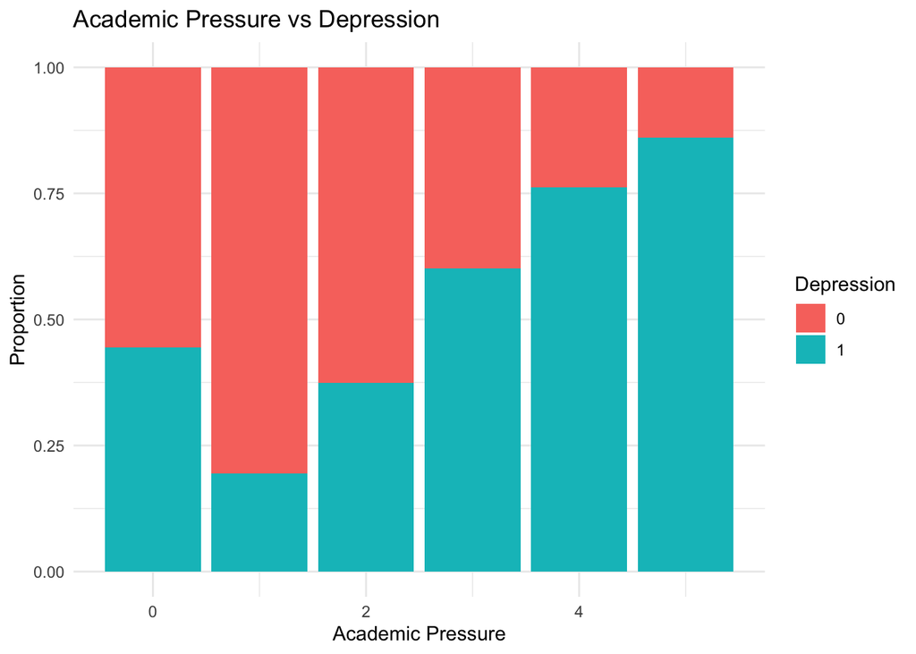

```r
ggplot(data_clean, aes(x = Academic.Pressure, fill = Depression)) +
  geom_bar(position = "fill") +
  labs(
    title = "Academic Pressure vs Depression",
    x = "Academic Pressure",
    y = "Proportion",
    fill = "Depression"
  ) +
  theme_minimal()
```

The visualization shows a clear relationship between academic pressure and depression levels. As academic pressure increases, the proportion of students reporting depression also increases.

##### 4.2 Sleep Duration vs Depression

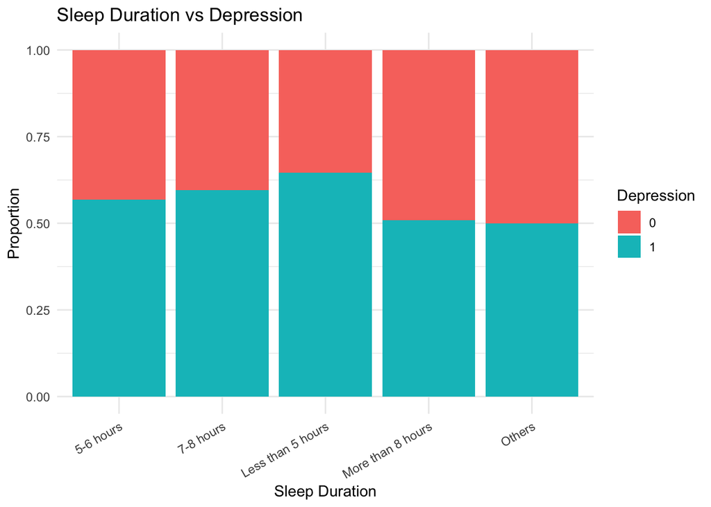

```r
ggplot(data_clean, aes(x = Sleep.Duration, fill = Depression)) +
  geom_bar(position = "fill") +
  labs(
    title = "Sleep Duration vs Depression",
    x = "Sleep Duration",
    y = "Proportion",
    fill = "Depression"
  ) +
  theme_minimal() +
  theme(axis.text.x = element_text(angle = 30, hjust = 1))
```

Students with shorter sleep durations tend to show a higher proportion of depression. This indicates a potential relationship between inadequate sleep and mental health deterioration. Sleep duration appears to be an important lifestyle factor influencing depression levels.

##### 4.3 Financial Stress vs Depression

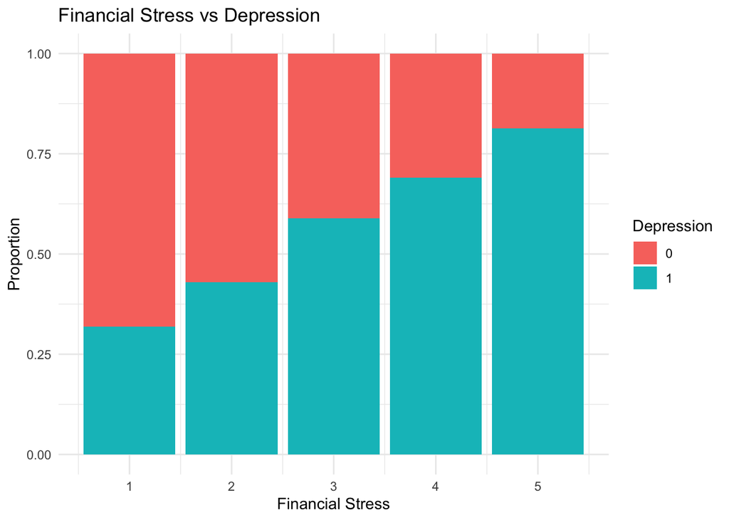

```r
ggplot(data_clean, aes(x = Financial.Stress, fill = Depression)) +
  geom_bar(position = "fill") +
  labs(
    title = "Financial Stress vs Depression",
    x = "Financial Stress",
    y = "Proportion",
    fill = "Depression"
  ) +
  theme_minimal()
```

Higher financial stress levels are associated with a greater proportion of depression cases. This suggests that economic pressure plays a significant role in student mental health and may act as one of the key hidden drivers of depression.

##### 4.4 Suicidal Thoughts vs Depression

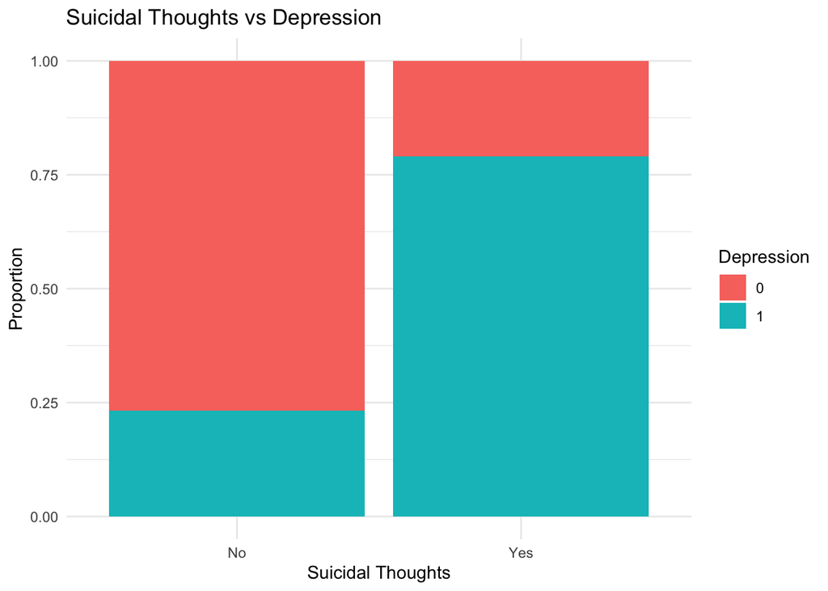

```r
ggplot(data_clean, aes(x = Have.you.ever.had.suicidal.thoughts.., fill = Depression)) +
  geom_bar(position = "fill") +
  labs(
    title = "Suicidal Thoughts vs Depression",
    x = "Suicidal Thoughts",
    y = "Proportion",
    fill = "Depression"
  ) +
  theme_minimal()
```

There is a very strong association between suicidal thoughts and depression. Students who reported suicidal thoughts show a significantly higher proportion of depression cases. This variable appears to be one of the strongest indicators of mental health condition in the dataset.

#### 4. Correlation Analysis

corelation matrix

```r
num_data <- data_clean[, num_vars_manual]
corr_matrix <- cor(num_data, use = "complete.obs")
print(corr_matrix)
```

```
##                              Age         CGPA Academic.Pressure
## Age                 1.0000000000  0.005074096       -0.07585445
## CGPA                0.0050740965  1.000000000       -0.02225165
## Academic.Pressure  -0.0758544491 -0.022251646        1.00000000
## Financial.Stress   -0.0950261000  0.005885102        0.15170587
## Work.Study.Hours   -0.0330003841  0.002637831        0.09605319
## Study.Satisfaction  0.0092394108 -0.044167391       -0.11108574
## Job.Satisfaction   -0.0004314306 -0.053634694       -0.02494774
##                    Financial.Stress Work.Study.Hours Study.Satisfaction
## Age                    -0.095026100     -0.033000384        0.009239411
## CGPA                    0.005885102      0.002637831       -0.044167391
## Academic.Pressure       0.151705865      0.096053191       -0.111085739
## Financial.Stress        1.000000000      0.075283261       -0.065106856
## Work.Study.Hours        0.075283261      1.000000000       -0.036356075
## Study.Satisfaction     -0.065106856     -0.036356075        1.000000000
## Job.Satisfaction        0.005248004     -0.005221004       -0.021909791
##                    Job.Satisfaction
## Age                   -0.0004314306
## CGPA                  -0.0536346943
## Academic.Pressure     -0.0249477369
## Financial.Stress       0.0052480036
## Work.Study.Hours      -0.0052210036
## Study.Satisfaction    -0.0219097911
## Job.Satisfaction       1.0000000000
```

Visualize correlation (Heatmap)

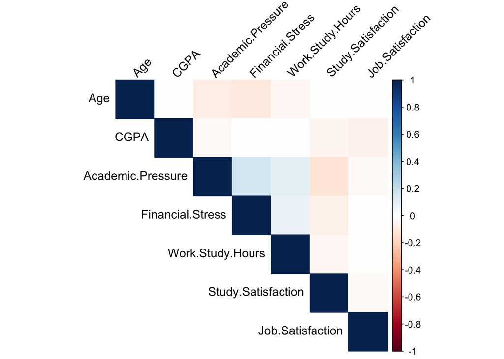

```r
library(corrplot)

corrplot(corr_matrix, method = "color", type = "upper",
         tl.col = "black", tl.srt = 45)
```

The correlation analysis reveals that most numerical variables exhibit weak relationships with one another, with no correlation exceeding 0.3. This indicates that each variable contributes independently to the analysis.

Interestingly, CGPA demonstrates minimal correlation with other variables, indicating that academic performance alone may not be a strong determinant of stress or mental health outcomes.

Overall, the findings suggest that student depression is influenced by a combination of multiple weakly correlated factors rather than a single dominant variable, reinforcing the concept of “hidden drivers” explored in this study.

### C. Data Preprocessing

Ensure target is numeric

```r
data_clean$Depression <- as.numeric(as.character(data_clean$Depression))
```

#### 1. Binary encoding

```r
data_clean$Have.you.ever.had.suicidal.thoughts.. <- ifelse(
  data_clean$Have.you.ever.had.suicidal.thoughts.. == "Yes", 1, 0
)

data_clean$Family.History.of.Mental.Illness <- ifelse(
  data_clean$Family.History.of.Mental.Illness == "Yes", 1, 0
)
```

#### 2. Catagorical Encoding

```r
data_clean$Gender <- as.factor(data_clean$Gender)
data_clean$City <- as.factor(data_clean$City)
data_clean$Degree <- as.factor(data_clean$Degree)
data_clean$Sleep.Duration <- as.factor(data_clean$Sleep.Duration)
data_clean$Dietary.Habits <- as.factor(data_clean$Dietary.Habits)
```

New Encoded Dataframe

```r
data_encoded <- model.matrix(~ Gender + City + Degree + Sleep.Duration + Dietary.Habits - 1, data = data_clean)

data_encoded <- as.data.frame(data_encoded)
```

#### 3. Combine with Numerical Data

```r
num_binary_data <- data_clean[, c(
  "Age",
  "CGPA",
  "Academic.Pressure",
  "Financial.Stress",
  "Work.Study.Hours",
  "Study.Satisfaction",
  "Job.Satisfaction",
  "Have.you.ever.had.suicidal.thoughts..",
  "Family.History.of.Mental.Illness",
  "Depression"
)]
```

Final Dataframne

```r
final_data <- cbind(num_binary_data, data_encoded)
```

#### 4. Feature Scaling

#### 4.1. Scale numerical columns

```r
numeric_cols <- c(
  "Age",
  "CGPA",
  "Academic.Pressure",
  "Financial.Stress",
  "Work.Study.Hours",
  "Study.Satisfaction",
  "Job.Satisfaction"
)

final_data[numeric_cols] <- scale(final_data[numeric_cols])
```

To prepare the dataset for modeling, several preprocessing steps were applied.

Binary variables such as suicidal thoughts and family history of mental illness were encoded into numerical form (0 and 1). Categorical variables including gender, city, degree, sleep duration, and dietary habits were transformed using one-hot encoding to make them suitable for machine learning algorithms.

Numerical variables were standardized using feature scaling to ensure that all features contribute equally to the model and prevent bias due to differences in scale.

The final dataset was constructed by combining numerical, binary, and encoded categorical features into a single structured format suitable for modeling.

### D. Modeling

#### 1. Splitting Train (80%) and Test(20%)

```r
set.seed(42)

train_index <- sample(1:nrow(final_data), 0.8 * nrow(final_data))

train_data <- final_data[train_index, ]
test_data  <- final_data[-train_index, ]
```

#### 2. Train Regression model

```r
model <- glm(
  Depression ~ Age + CGPA + Academic.Pressure + Financial.Stress +
    Work.Study.Hours + Study.Satisfaction +
    Have.you.ever.had.suicidal.thoughts.. +
    Family.History.of.Mental.Illness,
  data = train_data,
  family = "binomial"
)

summary(model)
```

```
##
## Call:
## glm(formula = Depression ~ Age + CGPA + Academic.Pressure + Financial.Stress +
##     Work.Study.Hours + Study.Satisfaction + Have.you.ever.had.suicidal.thoughts.. +
##     Family.History.of.Mental.Illness, family = "binomial", data = train_data)
##
## Coefficients:
##                                       Estimate Std. Error z value Pr(>|z|)
## (Intercept)                           -1.11730    0.03800 -29.404  < 2e-16 ***
## Age                                   -0.54302    0.02061 -26.345  < 2e-16 ***
## CGPA                                   0.08580    0.01992   4.307 1.65e-05 ***
## Academic.Pressure                      1.15973    0.02244  51.690  < 2e-16 ***
## Financial.Stress                       0.80315    0.02092  38.400  < 2e-16 ***
## Work.Study.Hours                       0.42679    0.02021  21.113  < 2e-16 ***
## Study.Satisfaction                    -0.31812    0.02020 -15.750  < 2e-16 ***
## Have.you.ever.had.suicidal.thoughts..  2.50599    0.04278  58.582  < 2e-16 ***
## Family.History.of.Mental.Illness       0.23682    0.03986   5.942 2.82e-09 ***
## ---
## Signif. codes:  0 '***' 0.001 '**' 0.01 '*' 0.05 '.' 0.1 ' ' 1
##
## (Dispersion parameter for binomial family taken to be 1)
##
##     Null deviance: 30229  on 22317  degrees of freedom
## Residual deviance: 16163  on 22309  degrees of freedom
## AIC: 16181
##
## Number of Fisher Scoring iterations: 5
```

#### 3. Prediction

```r
prob_predictions <- predict(model, test_data, type = "response")

predictions <- ifelse(prob_predictions > 0.5, 1, 0)
```

A logistic regression model was implemented to predict the likelihood of student depression based on lifestyle, academic, and behavioral factors.

Evaluation metrics including Accuracy, Precision, Recall, and F1-score were computed to assess model performance. These metrics provide a comprehensive understanding of the model’s ability to correctly identify both depressed and non-depressed students.

### E. Evaluation & Interpretation

#### 1. Confusion Matrix

```r
table(Predicted = predictions, Actual = test_data$Depression)
```

```
##          Actual
## Predicted    0    1
##         0 1900  376
##         1  489 2815
```

#### 2. Accuracy

```r
accuracy <- mean(predictions == test_data$Depression)
accuracy
```

```
## [1] 0.8449821
```

#### 3. Precision

```r
precision <- sum(predictions == 1 & test_data$Depression == 1) /
             sum(predictions == 1)
precision
```

```
## [1] 0.8519976
```

#### 4. Recall

```r
recall <- sum(predictions == 1 & test_data$Depression == 1) /
          sum(test_data$Depression == 1)
recall
```

```
## [1] 0.8821686
```

#### 5. F1 Score

```r
f1 <- 2 * (precision * recall) / (precision + recall)
f1
```

```
## [1] 0.8668206
```

Overall, the model provides reliable predictive capability and is suitable for identifying key factors associated with student depression.

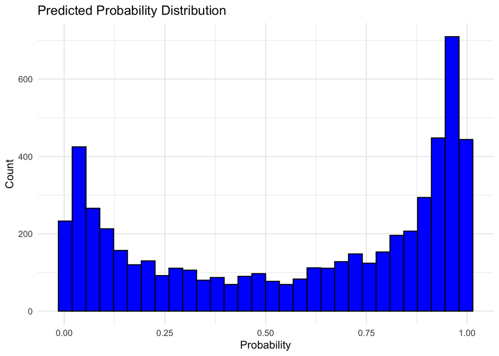

```r
ggplot(data.frame(prob_predictions), aes(x = prob_predictions)) +
  geom_histogram(bins = 30, fill = "blue", color = "black") +
  labs(title = "Predicted Probability Distribution", x = "Probability", y = "Count") +
  theme_minimal()
```

```r
summary(model)
```

```
##
## Call:
## glm(formula = Depression ~ Age + CGPA + Academic.Pressure + Financial.Stress +
##     Work.Study.Hours + Study.Satisfaction + Have.you.ever.had.suicidal.thoughts.. +
##     Family.History.of.Mental.Illness, family = "binomial", data = train_data)
##
## Coefficients:
##                                       Estimate Std. Error z value Pr(>|z|)
## (Intercept)                           -1.11730    0.03800 -29.404  < 2e-16 ***
## Age                                   -0.54302    0.02061 -26.345  < 2e-16 ***
## CGPA                                   0.08580    0.01992   4.307 1.65e-05 ***
## Academic.Pressure                      1.15973    0.02244  51.690  < 2e-16 ***
## Financial.Stress                       0.80315    0.02092  38.400  < 2e-16 ***
## Work.Study.Hours                       0.42679    0.02021  21.113  < 2e-16 ***
## Study.Satisfaction                    -0.31812    0.02020 -15.750  < 2e-16 ***
## Have.you.ever.had.suicidal.thoughts..  2.50599    0.04278  58.582  < 2e-16 ***
## Family.History.of.Mental.Illness       0.23682    0.03986   5.942 2.82e-09 ***
## ---
## Signif. codes:  0 '***' 0.001 '**' 0.01 '*' 0.05 '.' 0.1 ' ' 1
##
## (Dispersion parameter for binomial family taken to be 1)
##
##     Null deviance: 30229  on 22317  degrees of freedom
## Residual deviance: 16163  on 22309  degrees of freedom
## AIC: 16181
##
## Number of Fisher Scoring iterations: 5
```

The results indicate that student depression is influenced by multiple interconnected factors rather than a single dominant variable.

Additionally, increased work/study hours further elevate the likelihood of depression, reinforcing the role of workload intensity. In contrast, study satisfaction shows a negative relationship with depression, indicating that students who are more satisfied with their academic experience are less likely to experience mental health issues.

Age also demonstrates a protective effect, with older students showing lower levels of depression, possibly due to better coping mechanisms or experience.

Overall, the findings support the concept of “hidden drivers,” where depression is not caused by a single factor but rather a combination of academic, financial, and lifestyle pressures.